# Final_Project_Report

Binaya Shrestha, Dongming Li, Molly Buckler, Armando Castillo, John Langenwalter, Muhamad-Imran-Bin Maszeri

11/21/2020

## Introduction

- We are exploring two separate data sets and have combined the findings between them to see if there is any correlation between the two.
- Application
  - We chose lyme disease and weather data sets because it is known that lyme disease is carried by ticks. There may be some correlation between the disease and weather patterns such as precipitation since tick are exposed to the weather given their habitat and it could have an effect on the ticks population each year.

### Lyme Disease Background

**According to the CDC:**

- Lyme disease is a deer tick borne illness
- Lyme disease is the most common vector-borne disease in the United States
- Ticks usually lives outdoors, in tall grass or forest
- Transferred from tick to mammals through their bites
- Lyme disease is a bacteria
- Symptoms can include flu like symptoms as well as a bulls eye like rash

### Data Sets

- **Lyme Disease from 1992 - 2011**
  - Data set obtained from the CDC in csv format
  - Contains Lyme disease case data for counties inside the US from 1992 to 2011
  - The years are split up into 5 year increments
- **Global Historical Climentallegy daily**
  - Data sets obtained from NOAA in csv format and in txt format
  - Each csv file had the temperature and precipitation for each station every day for one year
  - Had to get the csv files for 1992 to 2011
  - The text file included data about the stations in the csv files, it includes which country the station is in, as well as which state the station is in
- **CDC Data Lyme Disease by Region 2007-2011**
  - Data is initially in the form of pdf files separated in each year in a 52 week format
  - Data is scraped from pdf files in each year into a csv format

## The pipeline for obtaining and cleaning the dataset

#### cleaning of the stations txt file

```
##   country state       code1     code2
## 1      US    SD US009052008 009052008
## 2      US    CO US10RMHS145 10RMHS145
## 3      US    NE US10adam001 10adam001
## 4      US    NE US10adam002 10adam002
## 5      US    NE US10adam003 10adam003
## 6      US    NE US10adam004 10adam004
```

#### Adding the text file to the dataframe

#### Merging csv files and grouping by the state by the info in txt file

```
##   country state       code1     code2
## 1      US    SD US009052008 009052008
## 2      US    CO US10RMHS145 10RMHS145
## 3      US    NE US10adam001 10adam001
## 4      US    NE US10adam002 10adam002
## 5      US    NE US10adam003 10adam003
## 6      US    NE US10adam004 10adam004
```

```
##          code prec1992 prec1993 prec1994 prec1995 prec1996 prec1997 prec1998
## 1 USC00010008 41.89344 33.34247 47.06849 38.19178 39.05769 41.19890 43.30685
## 2 USC00010140 38.03064 32.59178 34.64110 40.73425 35.92896 43.32123 41.74722
## 3 USC00010160 45.01639 31.63288 40.40000 35.80000 38.59836 47.14970 38.15068
## 4 USC00010178 36.41436 34.21714 38.69146 36.22993 40.01802 41.76584 33.65097
## 5 USC00010184 31.24863 34.40000 37.24110 39.96712 34.82787 37.41160 35.64932
## 6 USC00010252 43.28962 39.92055 44.95342 57.66189 40.71585 46.15934 57.80165
##   prec1999 prec2000 prec2001 prec2002 prec2003 prec2004 prec2005 prec2006
## 1 37.45509 26.37978 40.13333 38.15984 39.87397 39.83880 57.75150 33.81433
## 2 38.17260 25.95628 40.21053 44.31437 44.36986 41.30168 43.79944 38.92603
## 3 38.50137 35.30601 44.70411 35.43646 52.18563 37.42740 42.31233 32.44110
## 4 36.63692 31.96648 41.97923 51.14829 44.09200 35.16667 45.42500 44.36975
## 5 28.98356 31.29781 41.95890 33.57692 41.88767 37.40356 36.62192 30.70958
## 6 32.15342 26.09290 38.53846 47.17151 40.79062 43.16092 41.88889 25.64857
##   prec2007 prec2008 prec2009 prec2010 prec2011
## 1 29.28916 40.51093 61.08657 35.09926 31.58654
## 2 23.98904 36.20168 49.87397 32.29315 32.76712
## 3 24.46849 37.90385 56.67123 31.16438 33.69589
## 4 32.99457 32.66300 38.31771 35.02395 60.46411
## 5 23.10778 42.93716 57.36527 30.09041 40.39779
## 6 37.40828 37.87087 53.77091 39.27147 30.29752
```

```
##         code1 prec1992 prec1993 prec1994 prec1995 prec1996 prec1997 prec1998
## 1 USC00010008 41.89344 33.34247 47.06849 38.19178 39.05769 41.19890 43.30685
## 2 USC00010140 38.03064 32.59178 34.64110 40.73425 35.92896 43.32123 41.74722
## 3 USC00010160 45.01639 31.63288 40.40000 35.80000 38.59836 47.14970 38.15068
## 4 USC00010178 36.41436 34.21714 38.69146 36.22993 40.01802 41.76584 33.65097
## 5 USC00010184 31.24863 34.40000 37.24110 39.96712 34.82787 37.41160 35.64932
## 6 USC00010252 43.28962 39.92055 44.95342 57.66189 40.71585 46.15934 57.80165
##   prec1999 prec2000 prec2001 prec2002 prec2003 prec2004 prec2005 prec2006
## 1 37.45509 26.37978 40.13333 38.15984 39.87397 39.83880 57.75150 33.81433
## 2 38.17260 25.95628 40.21053 44.31437 44.36986 41.30168 43.79944 38.92603
## 3 38.50137 35.30601 44.70411 35.43646 52.18563 37.42740 42.31233 32.44110
## 4 36.63692 31.96648 41.97923 51.14829 44.09200 35.16667 45.42500 44.36975
## 5 28.98356 31.29781 41.95890 33.57692 41.88767 37.40356 36.62192 30.70958
## 6 32.15342 26.09290 38.53846 47.17151 40.79062 43.16092 41.88889 25.64857
##   prec2007 prec2008 prec2009 prec2010 prec2011 country state     code2
## 1 29.28916 40.51093 61.08657 35.09926 31.58654      US    AL C00010008
## 2 23.98904 36.20168 49.87397 32.29315 32.76712      US    AL C00010140
## 3 24.46849 37.90385 56.67123 31.16438 33.69589      US    AL C00010160
## 4 32.99457 32.66300 38.31771 35.02395 60.46411      US    AL C00010178
## 5 23.10778 42.93716 57.36527 30.09041 40.39779      US    AL C00010184
## 6 37.40828 37.87087 53.77091 39.27147 30.29752      US    AL C00010252
```

```
## # A tibble: 6 x 21
##   state prec1992 prec1993 prec1994 prec1995 prec1996 prec1997 prec1998 prec1999
##   <chr>    <dbl>    <dbl>    <dbl>    <dbl>    <dbl>    <dbl>    <dbl>    <dbl>
## 1 AK        33.1     32.0     31.1    29.9     24.0      31.2     31.2    34.7
## 2 AL        41.5     36.0     43.0    42.8     41.1      44.5     41.9    34.9
## 3 AR        34.2     37.1     39.0    30.2     35.7      35.7     33.9    30.1
## 4 AZ        15.5     14.6     10.9     9.74     7.81     10.8     11.4     8.73
## 5 CA        18.1     21.5     14.2    28.1     27.2      16.5     28.7    14.5
## 6 CO        15.0     16.9     14.0    18.9     17.4      18.4     15.5    16.4
## # ... with 12 more variables: prec2000 <dbl>, prec2001 <dbl>, prec2002 <dbl>,
## #   prec2003 <dbl>, prec2004 <dbl>, prec2005 <dbl>, prec2006 <dbl>,
## #   prec2007 <dbl>, prec2008 <dbl>, prec2009 <dbl>, prec2010 <dbl>,
## #   prec2011 <dbl>
```

#### Adding the text file to the dataframe

#### Merging csv files and grouping by the state by the info in txt file

#### Changing the temp data from 10th of a degree celcius to feriegnhight

```
##   country state       code1     code2
## 1      US    SD US009052008 009052008
## 2      US    CO US10RMHS145 10RMHS145
## 3      US    NE US10adam001 10adam001
## 4      US    NE US10adam002 10adam002
## 5      US    NE US10adam003 10adam003
## 6      US    NE US10adam004 10adam004
```

```
##         code1 temp1992 temp1993 temp1994 temp1995 temp1996 temp1997 temp1998
## 1 USC00010160 227.9178 232.2849 231.1616 235.0055 227.5902 228.7246 243.8055
## 2 USC00010178 227.9415 226.6629 230.7839 224.1636 199.7973 230.7887 245.7477
## 3 USC00010252 247.2944 250.1973 251.1554 272.5934 252.4411 255.6364 266.3140
## 4 USC00010369 214.2486 219.3444 220.4630 213.3977 209.8476 209.2057 217.9743
## 5 USC00010390 193.2521 195.6215 198.2775 212.4219 206.7760 205.9781 225.4164
## 6 USC00010402 237.2938 243.6548 245.7507 247.7355 244.3607 244.4822 258.5014
##   temp1999 temp2000 temp2001 temp2002 temp2003 temp2004 temp2005 temp2006
## 1 242.7802 239.6721 233.7989 231.5231 228.0601 229.4011 232.7701 246.6712
## 2 238.4601 265.0087 187.2333 228.4129 250.8000 216.1538 259.1844 274.7350
## 3 259.8652 264.3205 253.6630 256.0742 248.3026 255.1108 260.4050 271.1123
## 4 219.2090 223.4779 218.7591 220.7539 223.5866 226.4698 228.7583 238.6551
## 5 229.6767 218.5090 214.9973 218.6071 212.0411 214.7308 220.5207 234.3297
## 6 256.8685 261.3699 249.5699 267.7228 256.4000 246.8464 248.9466 265.2735
##   temp2007 temp2008 temp2009 temp2010 temp2011 country state     code2
## 1 249.2192 235.0932 228.8159 239.0904 242.2280      US    AL C00010160
## 2 317.1304 271.1055 188.8950 206.4819 247.7319      US    AL C00010178
## 3 265.9394 259.3743 255.0274 250.5644 259.8788      US    AL C00010252
## 4 251.9727 229.2079 223.5370 235.0529 241.0812      US    AL C00010369
## 5 237.0438 222.0712 219.5849 221.2632 222.9639      US    AL C00010390
## 6 257.8583 249.5522 246.1468 246.5994 255.6462      US    AL C00010402
```

```
##         code1 temp1992 temp1993 temp1994 temp1995 temp1996 temp1997 temp1998
## 1 USC00010160 73.02521 73.81129 73.60910 74.30099 72.96623 73.17042 75.88499
## 2 USC00010178 73.02947 72.79931 73.54111 72.34944 67.96351 73.54197 76.23459
## 3 USC00010252 76.51300 77.03551 77.20797 81.06681 77.43940 78.01455 79.93653
## 4 USC00010369 70.56475 71.48200 71.68334 70.41159 69.77258 69.65703 71.23537
## 5 USC00010390 66.78537 67.21188 67.68995 70.23595 69.21967 69.07605 72.57496
## 6 USC00010402 74.71288 75.85786 76.23512 76.59240 75.98492 76.00679 78.53025
##   temp1999 temp2000 temp2001 temp2002 temp2003 temp2004 temp2005 temp2006
## 1 75.70044 75.14098 74.08380 73.67416 73.05081 73.29220 73.89861 76.40082
## 2 74.92283 79.70157 65.70200 73.11433 77.14400 70.90769 78.65318 81.45231
## 3 78.77573 79.57770 77.65934 78.09335 76.69446 77.91994 78.87291 80.80022
## 4 71.45763 72.22602 71.37664 71.73570 72.24559 72.76456 73.17650 74.95791
## 5 73.34181 71.33162 70.69951 71.34929 70.16740 70.65154 71.69372 74.17934
## 6 78.23633 79.04658 76.92258 80.19010 78.15200 76.43235 76.81039 79.74923
##   temp2007 temp2008 temp2009 temp2010 temp2011 country state     code2
## 1 76.85945 74.31677 73.18687 75.03627 75.60104      US    AL C00010160
## 2 89.08348 80.79898 66.00110 69.16675 76.59175      US    AL C00010178
## 3 79.86909 78.68738 77.90493 77.10159 78.77818      US    AL C00010252
## 4 77.35509 73.25742 72.23666 74.30953 75.39462      US    AL C00010369
## 5 74.66789 71.97282 71.52528 71.82737 72.13350      US    AL C00010390
## 6 78.41450 76.91940 76.30643 76.38790 78.01632      US    AL C00010402
```

```
## # A tibble: 6 x 21
##   state temp1992 temp1993 temp1994 temp1995 temp1996 temp1997 temp1998 temp1999
##   <chr>    <dbl>    <dbl>    <dbl>    <dbl>    <dbl>    <dbl>    <dbl>    <dbl>
## 1 AK        44.0     46.5     42.0     41.3     40.1     42.2     41.6     38.9
## 2 AL        73.2     73.6     73.9     74.2     73.5     73.4     76.2     76.4
## 3 AR        71.2     70.6     71.5     72.4     70.9     70.9     74.0     74.5
## 4 AZ        72.5     73.5     74.5     74.6     75.4     73.7     72.4     74.7
## 5 CA        71.4     69.3     69.9     70.2     70.7     70.8     67.5     69.8
## 6 CO        55.8     53.8     57.5     55.9     56.6     55.4     56.8     57.5
## # ... with 12 more variables: temp2000 <dbl>, temp2001 <dbl>, temp2002 <dbl>,
## #   temp2003 <dbl>, temp2004 <dbl>, temp2005 <dbl>, temp2006 <dbl>,
## #   temp2007 <dbl>, temp2008 <dbl>, temp2009 <dbl>, temp2010 <dbl>,
## #   temp2011 <dbl>
```

#### Combining temp, lyme and prec

#### Seperating the years in prec dataframe

```
##   state prec9296 prec9701  prec0206  prec0711
## 1    AK 30.03502 32.78762 32.889984 30.594848
## 2    AL 40.86917 38.63870 40.490649 37.508912
## 3    AR 35.24217 33.89648 33.020549 39.289455
## 4    AZ 11.70490 10.04107  8.910686  9.631968
## 5    CA 21.82678 19.29065 18.539383 18.168128
## 6    CO 16.44359 15.74573 14.547319 15.843395
```

#### Seperating the years in the temp data frame

```
##   state temp9296 temp9701 temp0206  temp0711
## 1    AK 42.76686 40.96791 42.93860  41.91315
## 2    AL 73.67298 75.24713 74.87092 108.55998
## 3    AR 71.31659 72.86664 72.34949 102.69278
## 4    AZ 74.07920 73.96643 74.34672 104.67617
## 5    CA 70.29942 69.74416 70.32150  96.45437
## 6    CO 55.91277 57.09094 57.51184  72.07451
```

#### Cleaning the lyme disease data frame

```
##     state lyme9296 lyme9701 lyme0206 lyme0711
## 1 Alabama       NA       NA       NA        1
## 2 Alabama       NA        2       NA       NA
## 3 Alabama        4        4        1        1
## 4 Alabama       NA       NA       NA       NA
## 5 Alabama        1       NA       NA       NA
## 6 Alabama       NA       NA       NA       NA
```

```
##     state lyme9296
## 1 Alabama        4
## 2 Alabama        1
## 3 Alabama        1
## 4 Alabama        1
## 5 Alabama        1
## 6 Alabama        1
```

```
##         state lyme9296 lyme9701 lyme0206 lyme0711
## 1     Alabama       41       71       39       32
## 2     Arizona        1       13       41       17
## 3    Arkansas       81       53        3        1
## 4  California      581      619      411      471
## 5    Colorado        1        3        1        3
## 6 Connecticut     9792    16316    10980    12515
```

#### Adding state abbr to lyme disease

```
##          full lyme9296 lyme9701 lyme0206 lyme0711
## 1     Alabama       41       71       39       32
## 2     Arizona        1       13       41       17
## 3    Arkansas       81       53        3        1
## 4  California      581      619      411      471
## 5    Colorado        1        3        1        3
## 6 Connecticut     9792    16316    10980    12515
```

```
##         full lyme9296 lyme9701 lyme0206 lyme0711 state
## 1    Alabama       41       71       39       32    AL
## 2     Alaska        0        0        0        0    AK
## 3    Arizona        1       13       41       17    AZ
## 4   Arkansas       81       53        3        1    AR
## 5 California      581      619      411      471    CA
## 6   Colorado        1        3        1        3    CO
```

#### Combining 3 data sets

```
##   state       full lyme9296 lyme9701 lyme0206 lyme0711 temp9296 temp9701
## 1    AK     Alaska        0        0        0        0 42.76686 40.96791
## 2    AL    Alabama       41       71       39       32 73.67298 75.24713
## 3    AR   Arkansas       81       53        3        1 71.31659 72.86664
## 4    AZ    Arizona        1       13       41       17 74.07920 73.96643
## 5    CA California      581      619      411      471 70.29942 69.74416
## 6    CO   Colorado        1        3        1        3 55.91277 57.09094
##   temp0206  temp0711 prec9296 prec9701  prec0206  prec0711
## 1 42.93860  41.91315 30.03502 32.78762 32.889984 30.594848
## 2 74.87092 108.55998 40.86917 38.63870 40.490649 37.508912
## 3 72.34949 102.69278 35.24217 33.89648 33.020549 39.289455
## 4 74.34672 104.67617 11.70490 10.04107  8.910686  9.631968
## 5 70.32150  96.45437 21.82678 19.29065 18.539383 18.168128
## 6 57.51184  72.07451 16.44359 15.74573 14.547319 15.843395
```

## Exploratory Analysis

### Lyme Disease Changes from 1992-2011

Although temperature And precipitation remained roughly the same, lyme disease had a steady increase from 1992-2011

There is a steady increase of about 500 more new cases each 5 years.

**Averages cases**

- 1992-96: 1186.78
- 1997-01: 1611.50
- 2002-06: 2158.64
- 2007-11: 2658.22

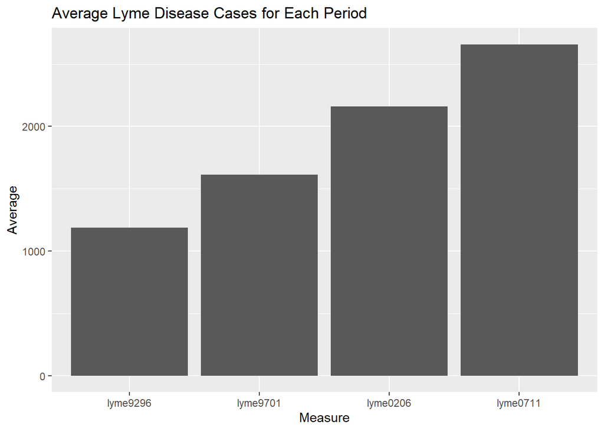

**Total number of cases**

- 1992-96: 59,339
- 1997-01: 80,575
- 2002-06: 107,932
- 2007-11: 132,911
- Total = 380,757

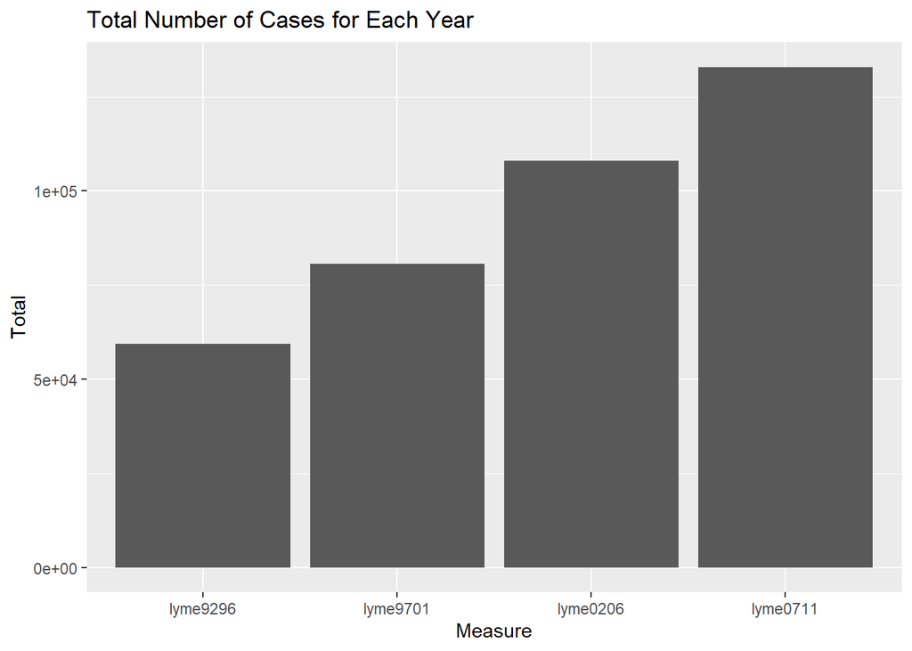

The average temperature nationwide for each 5 year block remained roughly the same

**Average temperature**

- 1992-96: 62.90
- 1997-01: 63.94
- 2002-06: 63.82
- 2007-11: 63.27

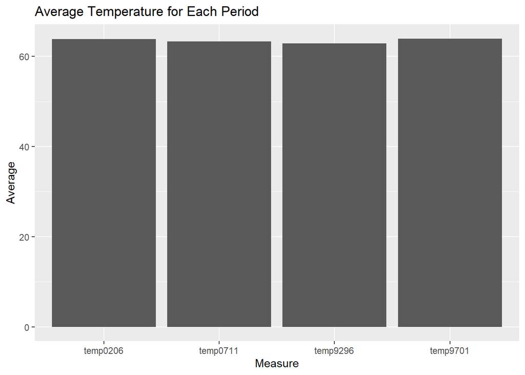

The average precipitation nationwide for each 5 year block remained roughly the same

**Average precipitation**

- 1992-96: 28.23
- 1997-01: 26.37
- 2002-06: 27.90
- 2007-11: 28.70

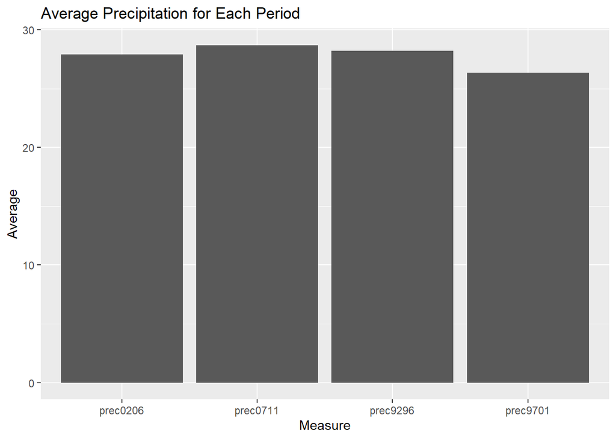

### Lyme Disease Affected States

Here we can look at which states were most affected by Lyme disease.

From the maps below we can start to see that the upper right region of the US has a high amount of cases and as we move from 1999 to 2011 the disease is spreading towards the northern central states.

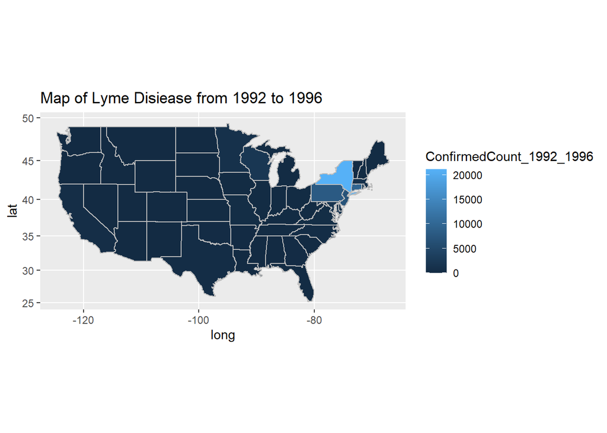

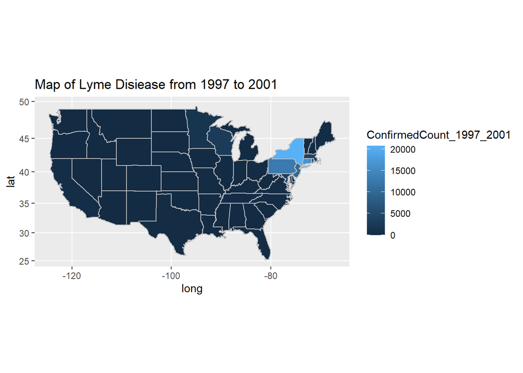

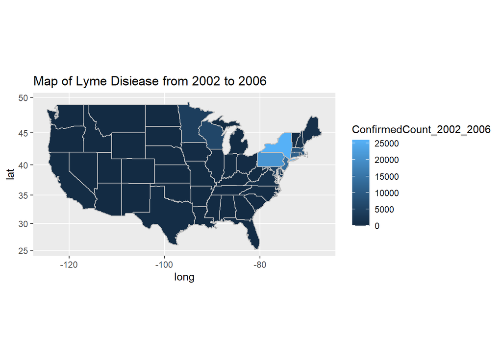

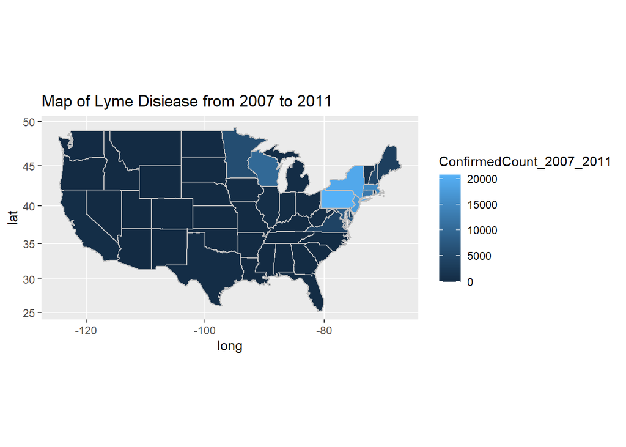

#### **Cases from 1992-1996**

- New York had the most amount of lyme disease cases with 21,205 cases.

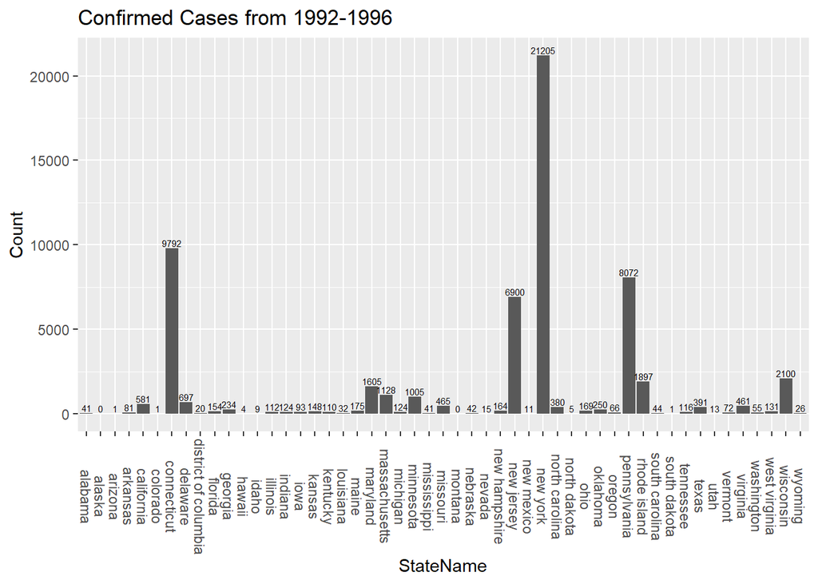

#### **Cases from 1997-2001**

- New York had the most amount of lyme disease cases and ended up with slightly few cases at 20,781.
- Connecticut saw a massive rise in cases from 9,792 to 16,316 cases.
- Pennsylvania and New Jersey also saw a significant rise in cases.

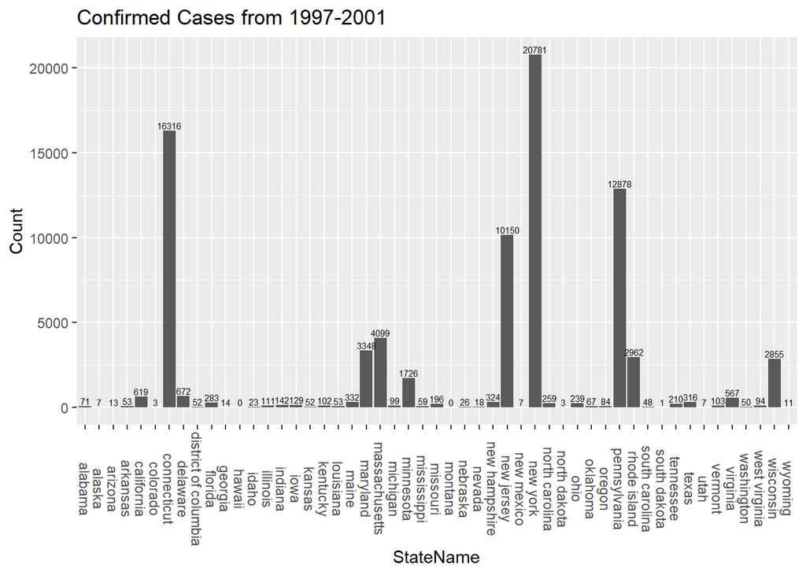

#### **Cases from 2002-2006**

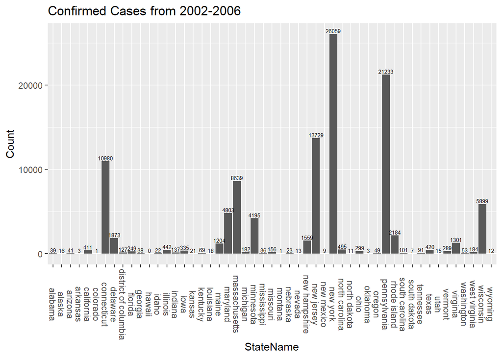

#### **Cases from 2007-2011**

- Pennsylvania had the most amount of lyme disease cases with 20,799 cases.
- More states with higher counts lyme disease cases

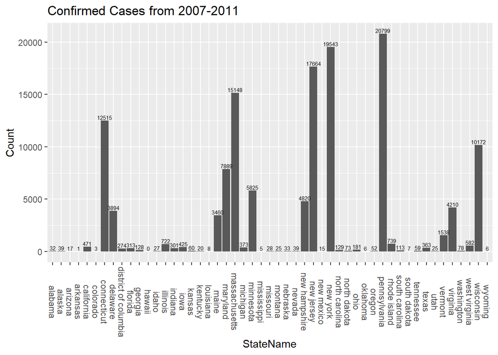

### Lyme Disease Affected Region from 2007-2011

We can see that the distribution of lyme disease is mainly around the Mid Atlantic and New England region. These regions are part of the north eastern part of the US. This finding matches with the map data shown previously.

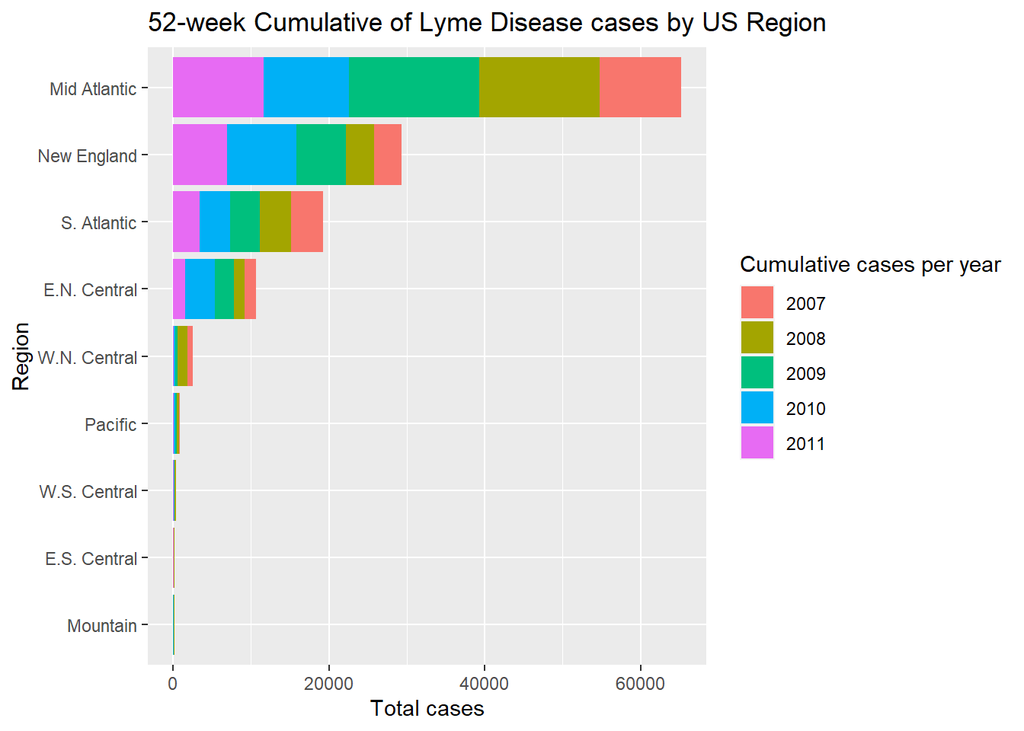

### Lyme Disease Affected State from 2007-2011

- States that are affected are align with the CDC region data
- States are mostly located northeast or north of the Midwest

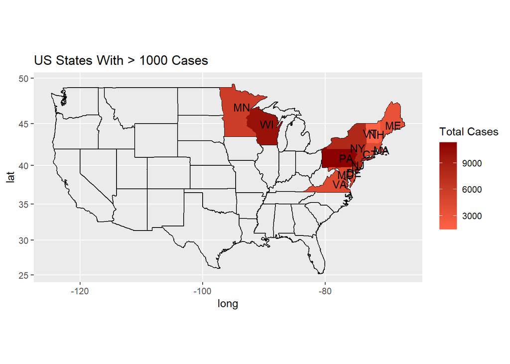

### Lyme Disease Affected Counties from 2007-2011

- Counties in the Northeast are located close to the ocean
- Counties in North Central Midwest are mostly located on the state capital where most people are located
- Same can be said with Northeast states, places with high population

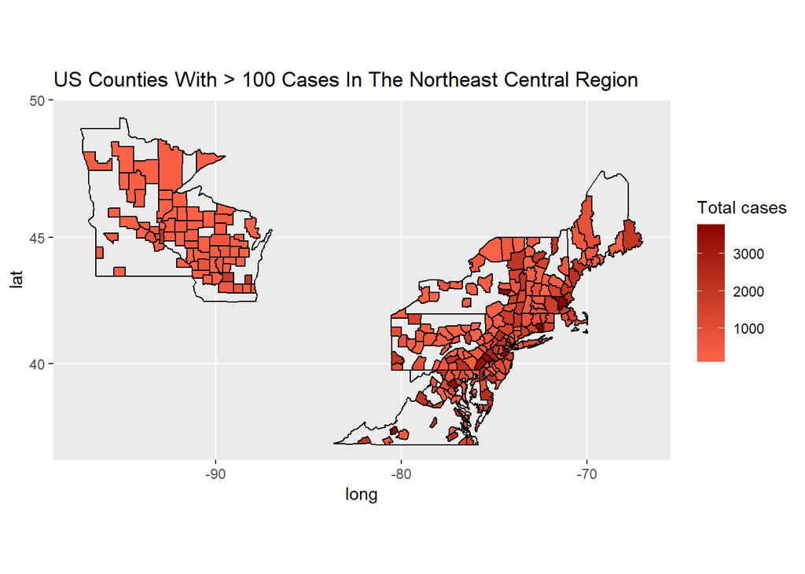

## Temperature Difference in US between 2007-2011

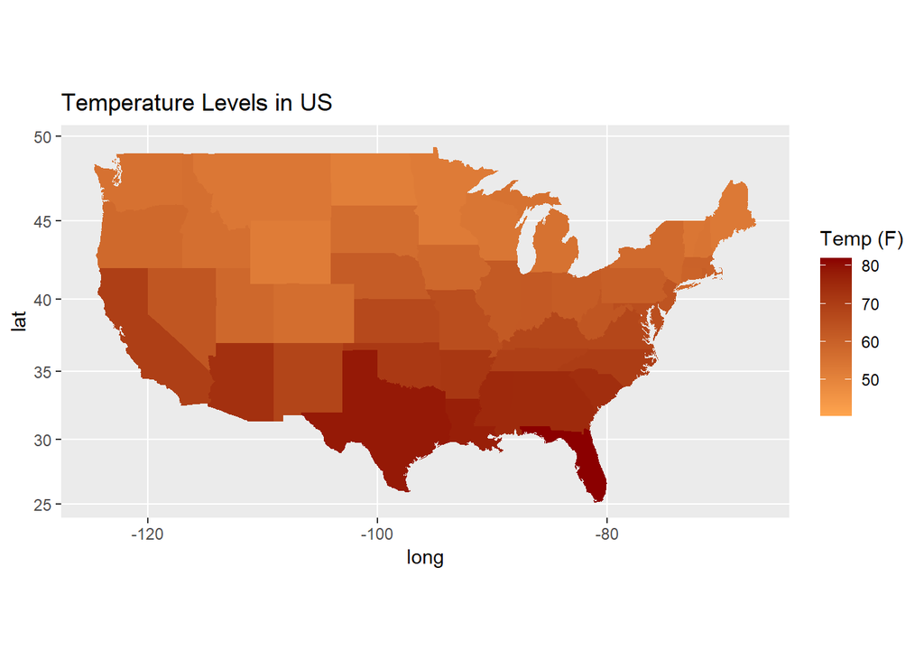

### The change of average temperature in the U.S. and each states may affect the rate of Lymn disease.

The average temperature for each state varies by a lot.

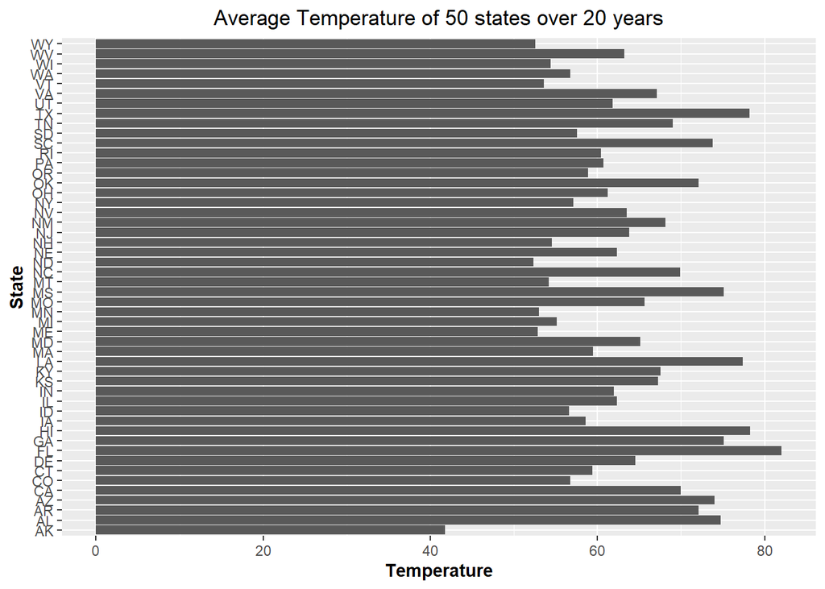

### Average Temperature over 20 years

The average temperature in the United States has been between 60 and 65 degrees Fahrenheit over 20 years.

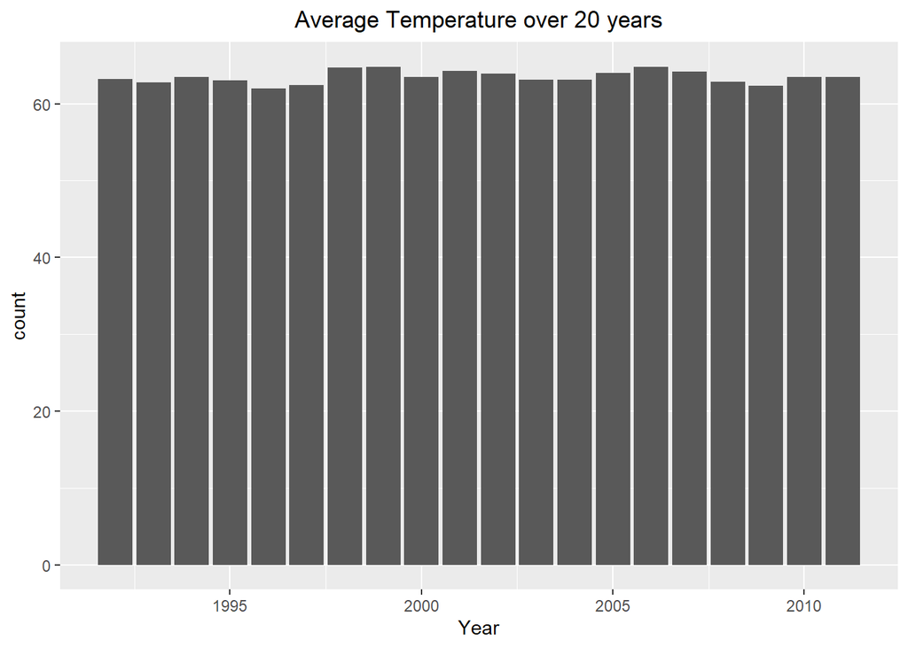

### Temperature Changes from 1992-2011

Here we can see how has the average temperature in the United States has changed over 20 years.

Although the average temperature in these states may rise or fall each year, the overall trend of average temperature is still a gradual upward trend.

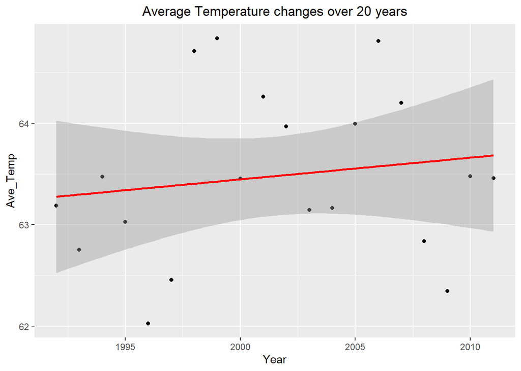

### Amount of Lyme Disease for Different Temperatures

Here we can see the correlation between Temp and Lymn disease.

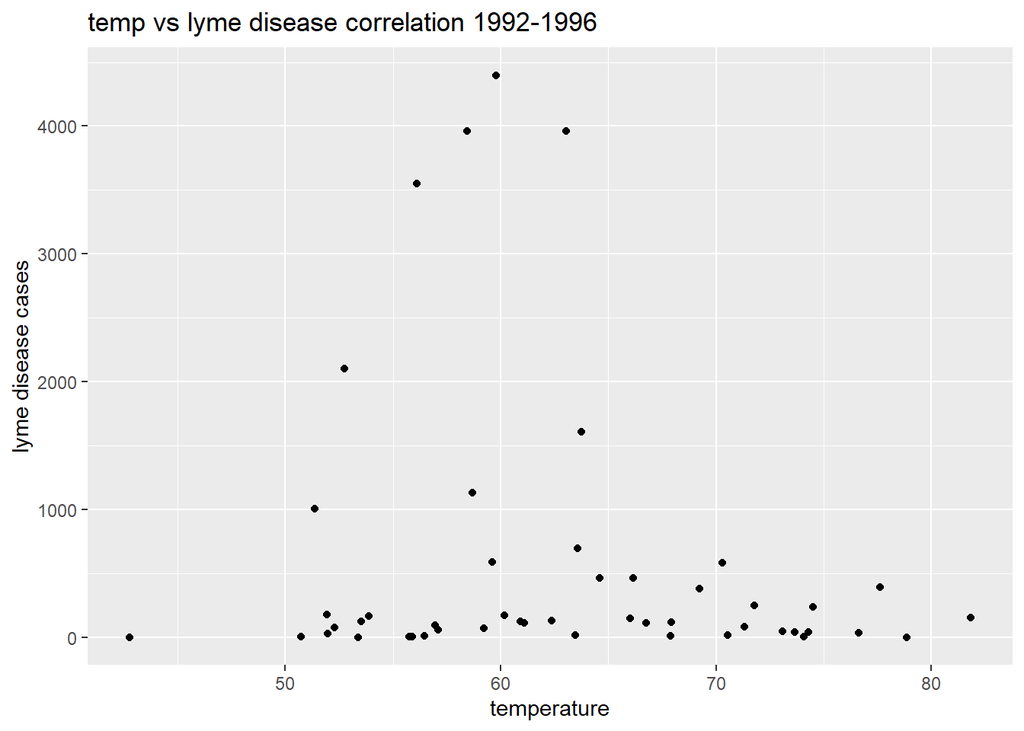

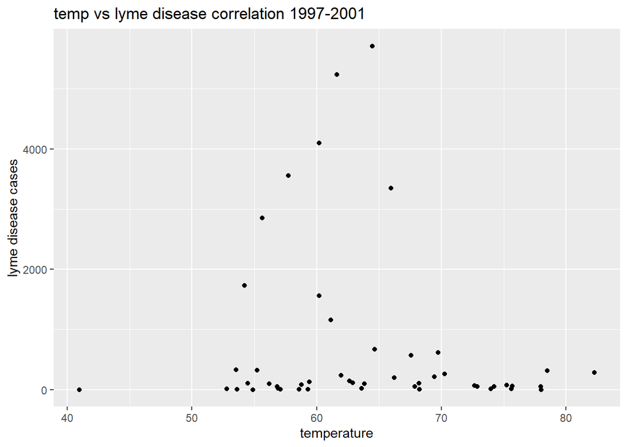

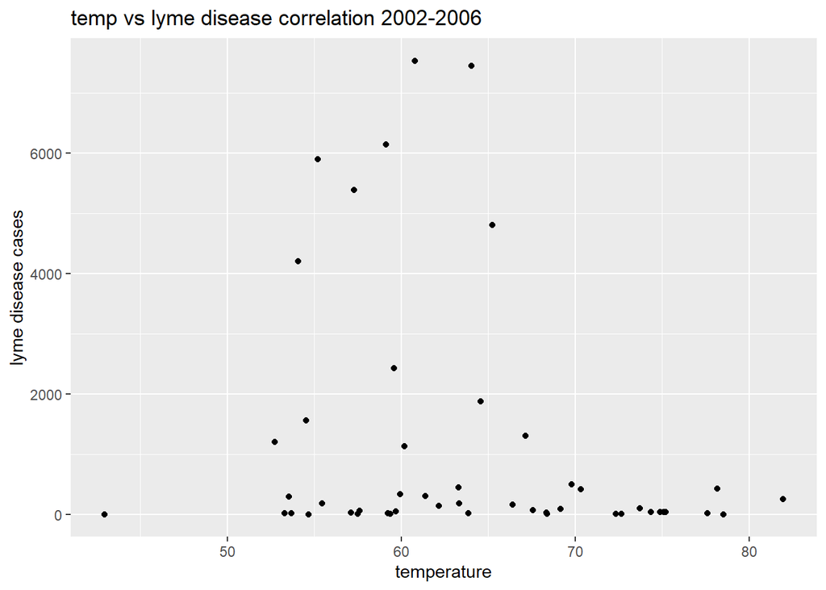

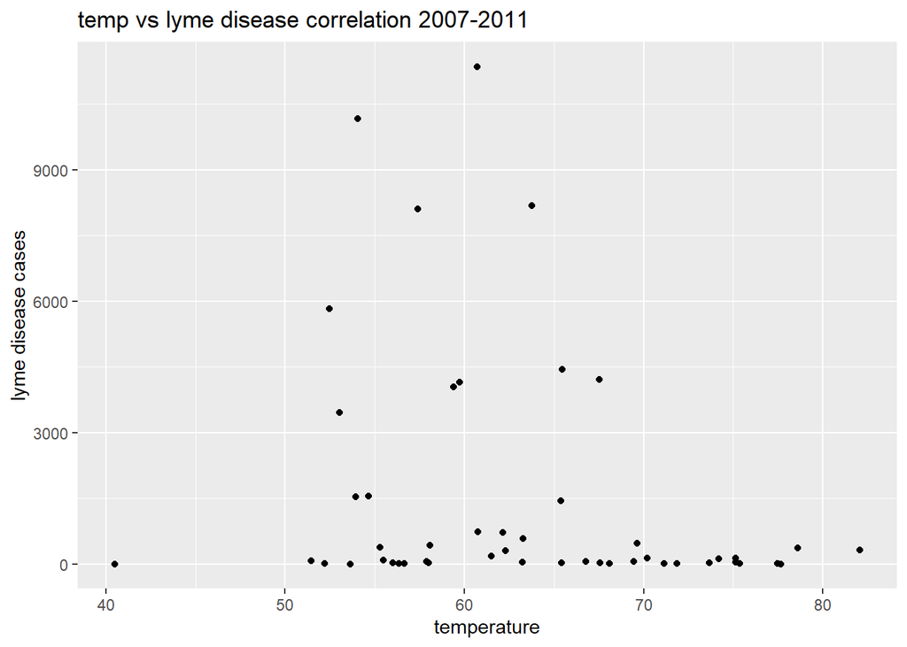

### Scatterplot to show Peak temperatures for lyme disease cases

We can see that when the above graphs are combined together that Lyme disease typically happens when the temperature is around the range of 60 degrees.

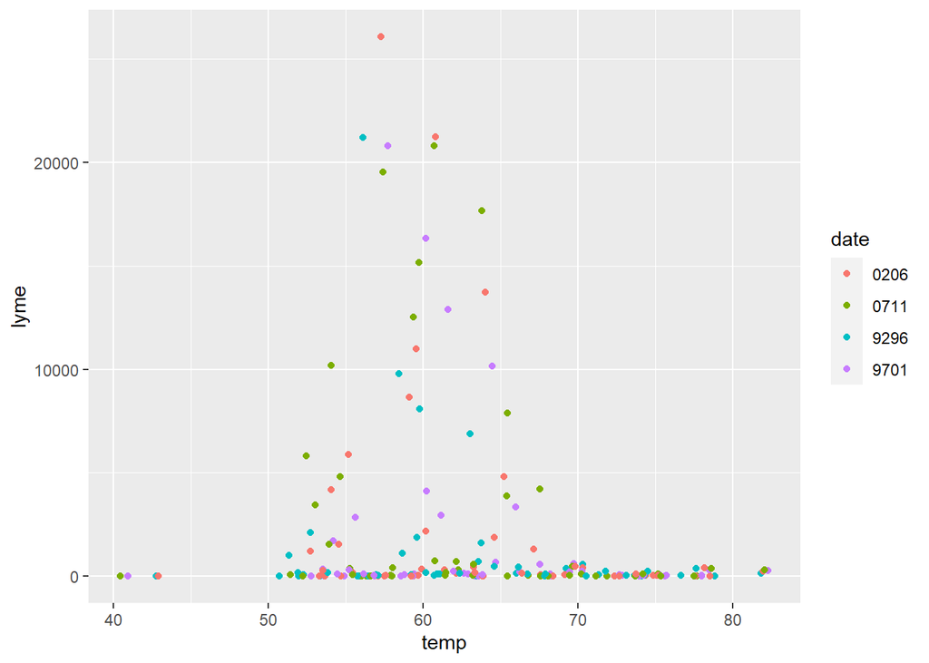

### Association of Lyme disease to changes in Temperature

We found that between 55-65 fahrenheit are where most of the lyme disease cases start to peak. We modeled lyme disease cases versus temperature throughout the years 1992-2011. The pattern was consistent through the years the the avg temperate of 60 f was very dangerous due to the amount of high cases of lyme disease.

### Precipitation Difference in US between 2007-2011

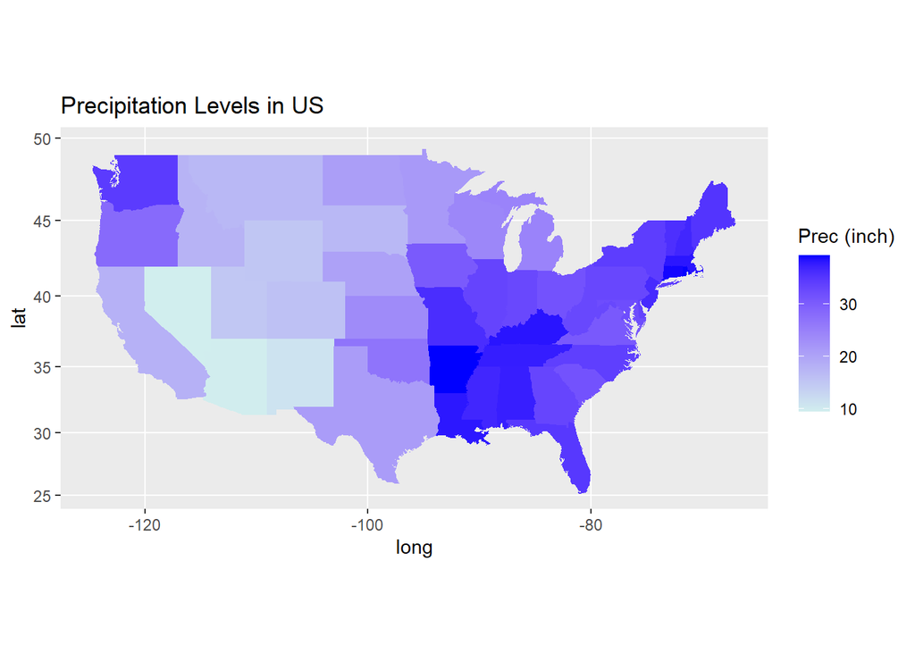

### Average Precipitation

The average precipitation does not change very much from each year but there are several peaks in certain years such as 1996 and 2011.

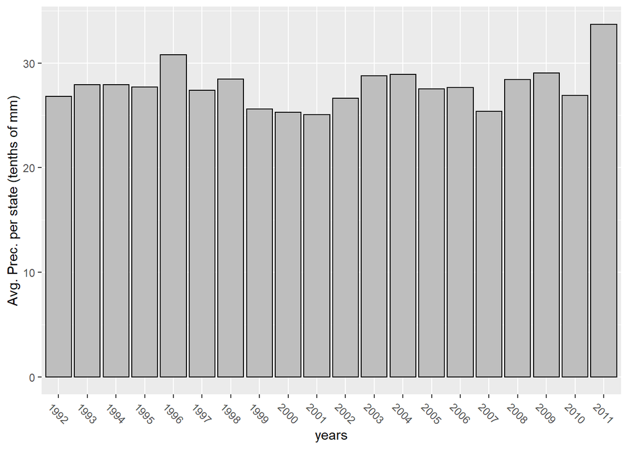

### Correlation between Lyme disease and precipitation

The p- value is very large so the correlation is not significant

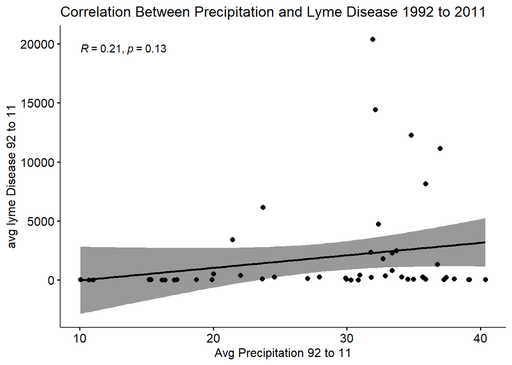